# Linear regression

2023-10-18T17:26:23-05:00

Linear regression is a linear approach for modelling the relationship between a scalar response and one or more explanatory variables (also known as dependent and independent variables). The case of one explanatory variable is called simple linear regression; for more than one, the process is called multiple linear regression. This term is distinct from multivariate linear regression, where multiple correlated dependent variables are predicted, rather than a single scalar variable.

Linear regression models are often fitted using the `least squares` approach, but they may also be fitted in other ways, such as by minimizing the “lack of fit” in some other norm (as with least absolute deviations regression), or by minimizing a penalized version of the least squares cost function as in ridge regression (${L2-norm}$ penalty) and lasso (${L1-norm}$ penalty). Conversely, the `least squares` approach can be used to fit models that are not linear models. Thus, although the terms “least squares” and “linear model” are closely linked, they are not synonymous.

In this exercise series of linear regression, we will look at some problems to better understand the use case of linear regression.

## Part 1

Consider the fitted values that result from performing linear regression without an intercept. In this setting, the $i-th$ fitted value takes the form $\hat{y_i} = x_i\hat{\beta}$, where
$$\hat{\beta} = \frac{\sum_{i=1}^n
x_iy_i}{\sum_{i'=1}^nx_{i'}^2}.$$

Show that we can write:

$$\hat{y}_i =
\sum_{i=1}^na_iy_i.$$

What is $a_{i'}$ ?

Note: we interpret this result by saying that the fitted values from linear regression are linear combinations of the response values.

Here, we can write:
$$\hat{y}_i =
x_i\frac{\sum_{i=1}^n
x_iy_i}{\sum_{i'=1}^nx_{i'}^2}$$

Where
$$\frac{x_i}{\sum_{i'=1}^nx_{i'}^2}$$
is a constant value for each $i^{th}$ which can be represented as $c_{i'}$. If we have this on the equation above, we get:

$$\hat{y}_i = c_{i'}{\sum_{i=1}^n
x_iy_i} = {\sum_{i=1}^n c_{i'}x_iy_i}$$

When we combine $c_{i'}$ with $x_i$, we get $a_{i'}$. We could determine $a_{i'}$ as weight function over the $Y$ set to estimate the $y_i$ element.

Now, we will perform some data analyses using ${Carseats}$ dataset. First, we will fit a multiple regression model to predict Sales using Price, Urban, and US.

```r
library(ISLR)
library(knitr)
library(caret)
data(Carseats)
head(Carseats)
```

```
##   Sales CompPrice Income Advertising Population Price ShelveLoc Age Education
## 1  9.50       138     73          11        276   120       Bad  42        17
## 2 11.22       111     48          16        260    83      Good  65        10
## 3 10.06       113     35          10        269    80    Medium  59        12
## 4  7.40       117    100           4        466    97    Medium  55        14
## 5  4.15       141     64           3        340   128       Bad  38        13
## 6 10.81       124    113          13        501    72       Bad  78        16
##   Urban  US
## 1   Yes Yes
## 2   Yes Yes
## 3   Yes Yes
## 4   Yes Yes
## 5   Yes  No
## 6    No Yes
```

```r
## make the regression model
model_3.7.10.a=lm(Sales~Price+Urban+US,data=Carseats)
summary(model_3.7.10.a)
```

```
##
## Call:
## lm(formula = Sales ~ Price + Urban + US, data = Carseats)
##
## Residuals:
##     Min      1Q  Median      3Q     Max
## -6.9206 -1.6220 -0.0564  1.5786  7.0581
##
## Coefficients:
##              Estimate Std. Error t value Pr(>|t|)
## (Intercept) 13.043469   0.651012  20.036  < 2e-16 ***
## Price       -0.054459   0.005242 -10.389  < 2e-16 ***
## UrbanYes    -0.021916   0.271650  -0.081    0.936
## USYes        1.200573   0.259042   4.635 4.86e-06 ***
## ---
## Signif. codes:  0 '***' 0.001 '**' 0.01 '*' 0.05 '.' 0.1 ' ' 1
##
## Residual standard error: 2.472 on 396 degrees of freedom
## Multiple R-squared:  0.2393, Adjusted R-squared:  0.2335
## F-statistic: 41.52 on 3 and 396 DF,  p-value: < 2.2e-16
```

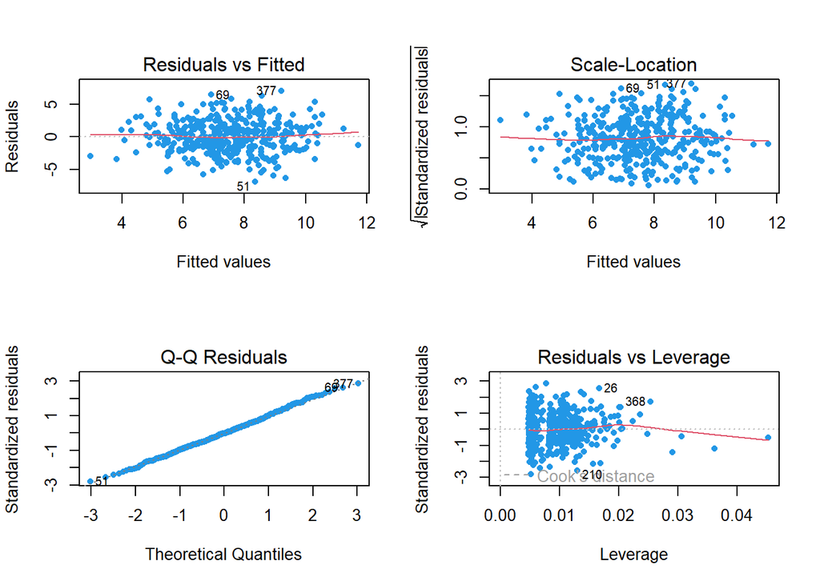

```r
layout(matrix(1:4,nrow=2))
plot(model_3.7.10.a,pch=16,col=4,cex=0.8)
```

Then we will provide an interpretation of each coefficient in the model. Be careful—some of the variables in the model are qualitative!

Given the Unit sales (which is in thousands) at each location, we can interpret the result as follows: if there is 1 dollar change in price, 54.4588492 units in sales will go down keeping all other predictors fixed. We can also say that the unit sales in urban location are 21.9161508 units less than in rural location keeping all other predictors fixed. Likewise, we can also say that on average the unit sales in a US store are 1200.5726978 units more than in a non US store keeping other predictors fixed.

Now, we write out the model in equation form, being careful to handle the qualitative variables properly.

$$Sales = 13.0434689 + (-0.0544588)\times
Price + (-0.0219162)\times Urban + (1.2005727)\times US +
\varepsilon$$

with $Urban = 1$ if the store is in an urban location and $0$ if not, and $US = 1$ if the store is in the US and $0$ if not.

Now, we will try to find out for which of the predictors we can reject the null hypothesis $H_0 : \beta_j = 0$ .

**Answer:**

For Price and US, we can reject the Null Hypothesis at any significance level. The p-value (P<0.05) is the threshold value at which we can reject the Null hypothesis.

On the basis of our response to the previous question, we will fit a smaller model that only uses the predictors for which there is evidence of association with the outcome.

```r
model_3.7.10.e=lm(Sales~Price+US,data=Carseats)
summary(model_3.7.10.e)
```

```
##
## Call:
## lm(formula = Sales ~ Price + US, data = Carseats)
##
## Residuals:
##     Min      1Q  Median      3Q     Max
## -6.9269 -1.6286 -0.0574  1.5766  7.0515
##
## Coefficients:
##             Estimate Std. Error t value Pr(>|t|)
## (Intercept) 13.03079    0.63098  20.652  < 2e-16 ***
## Price       -0.05448    0.00523 -10.416  < 2e-16 ***
## USYes        1.19964    0.25846   4.641 4.71e-06 ***
## ---
## Signif. codes:  0 '***' 0.001 '**' 0.01 '*' 0.05 '.' 0.1 ' ' 1
##
## Residual standard error: 2.469 on 397 degrees of freedom
## Multiple R-squared:  0.2393, Adjusted R-squared:  0.2354
## F-statistic: 62.43 on 2 and 397 DF,  p-value: < 2.2e-16
```

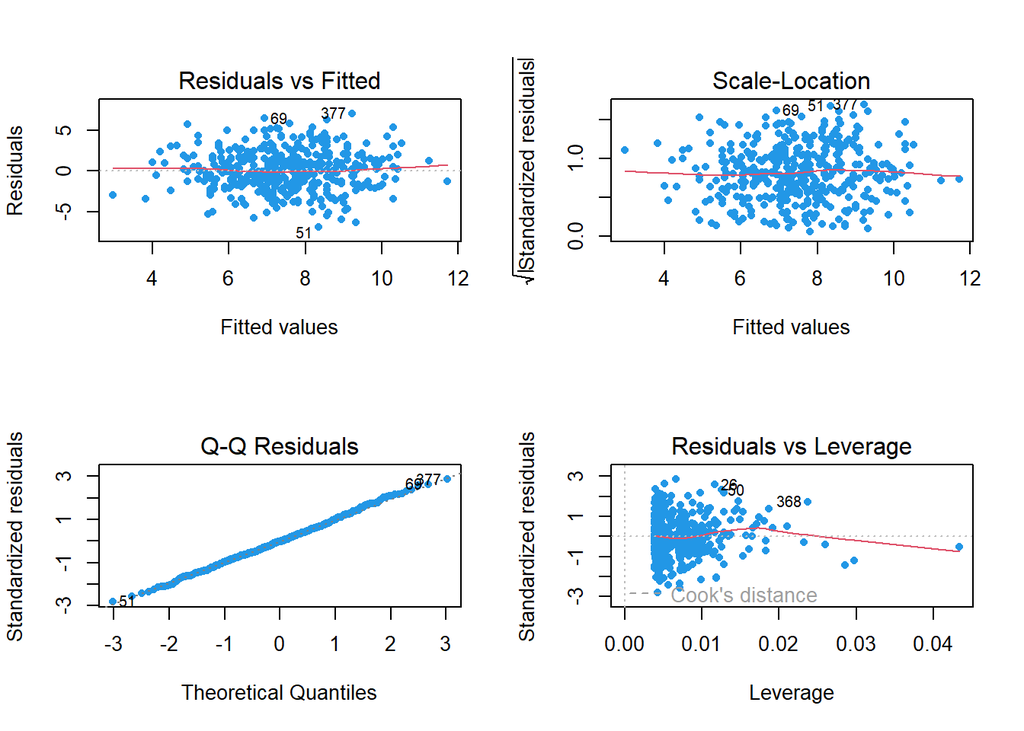

```r
layout(matrix(1:4,nrow=2))
plot(model_3.7.10.e,pch=16,col=4,cex=0.8)
```

In this previous model, we removed the Urban variable. Urban variable did not have enough evidence of linear association with Sales. The summary statistics from this model show that both Price and US have nearly zero p-values, suggesting good linear association. We can also tell that the estimates of the coefficients are almost the same as the previous model, but the adjusted R-squared value now has slightly gone up.

Now, see how well the models fit the data.

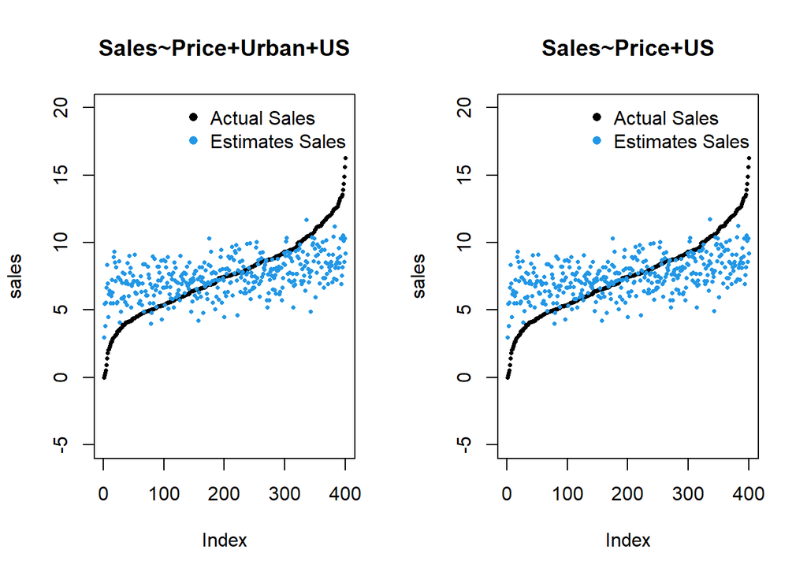

```r
## plots:
data=Carseats[order(Carseats$Sales),]
model_3.7.10.a=lm(Sales~Price+Urban+US,data=data)
model_3.7.10.e=lm(Sales~Price+US,data=data)
layout(matrix(1:2,nrow=1))
## model A
plot(data$Sales, col=1, cex=0.5,pch=16,ylim = c(-5,20), ylab="sales",
     main="Sales~Price+Urban+US")
points(model_3.7.10.a$fitted.values, col=4,cex=0.5,pch=16)
legend("topright",bty="n",c("Actual Sales","Estimates Sales"),
        col=c(1,4),pch=16)

## model E
plot(data$Sales, col=1, cex=0.5,pch=16,ylim = c(-5,20), ylab="sales",
     main="Sales~Price+US")
points(model_3.7.10.e$fitted.values, col=4,cex=0.5,pch=16)
legend("topright",bty="n",c("Actual Sales","Estimates Sales"),
       col=c(1,4),pch=16)
```

```r
cat ("Est std err of the error of model_3.7.10.a")
```

```
## Est std err of the error of model_3.7.10.a
```

```r
Aerror=sqrt(sum((model_3.7.10.a$residuals)^2)/model_3.7.10.a$df.residual)
Aerror
```

```
## [1] 2.472492
```

```r
cat ("Est std err of the error of model_3.7.10.e")
```

```
## Est std err of the error of model_3.7.10.e
```

```r
Eerror=sqrt(sum((model_3.7.10.e$residuals)^2)/model_3.7.10.e$df.residual)
Eerror
```

```
## [1] 2.469397
```

```r
cat("Mean sales: ")
```

```
## Mean sales:
```

```r
mean(data$Sales)
```

```
## [1] 7.496325
```

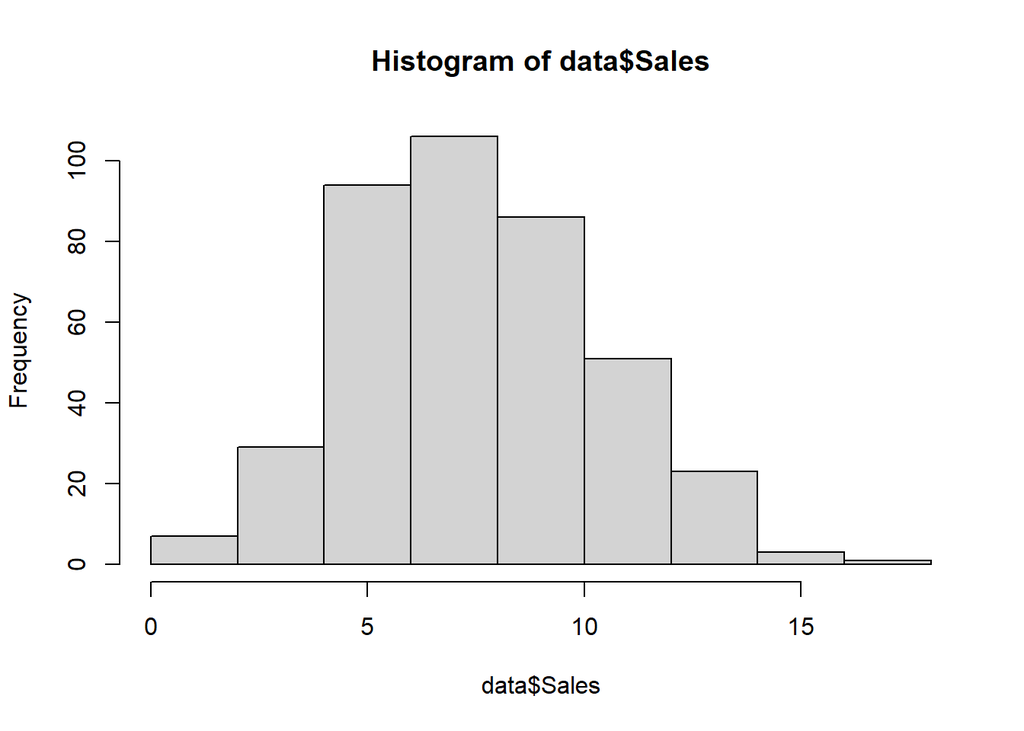

```r
layout(matrix(1))
hist(data$Sales)
```

```r
cat("Anova of model_3.7.10.a and model_3.7.10.e")
```

```
## Anova of model_3.7.10.a and model_3.7.10.e
```

```r
kable(anova(model_3.7.10.a,model_3.7.10.e), caption = "Anova of model_3.7.10.a and model_3.7.10.e")
```

Anova of model_3.7.10.a and model_3.7.10.e

| Res.Df | RSS | Df | Sum of Sq | F | Pr(>F) |
| --- | --- | --- | --- | --- | --- |
| 396 | 2420.835 | NA | NA | NA | NA |
| 397 | 2420.874 | -1 | -0.0397904 | 0.0065089 | 0.9357389 |

The adjusted R-squared values from the two models are 0.2335 (larger model) and 0.2354 (smaller model). So, i.e., [`summary(model_3.7.10.a)$r.sq` * `100`], which is roughly 23.9262888% (for smaller model) and 23.9275392% (for larger model) of the variability of the sales is explained by the models which means it doesn’t explain a lot.